# EDS 214 Project

This repository is for the EDS 214 project which its primary focus is to recreate figure 3 from Schaefer et al. 2000. This project will be open-ended in that functions, rendering, scripts and documentation will be either created or aiding in the recreation of the figure. Below is

the image of focus:

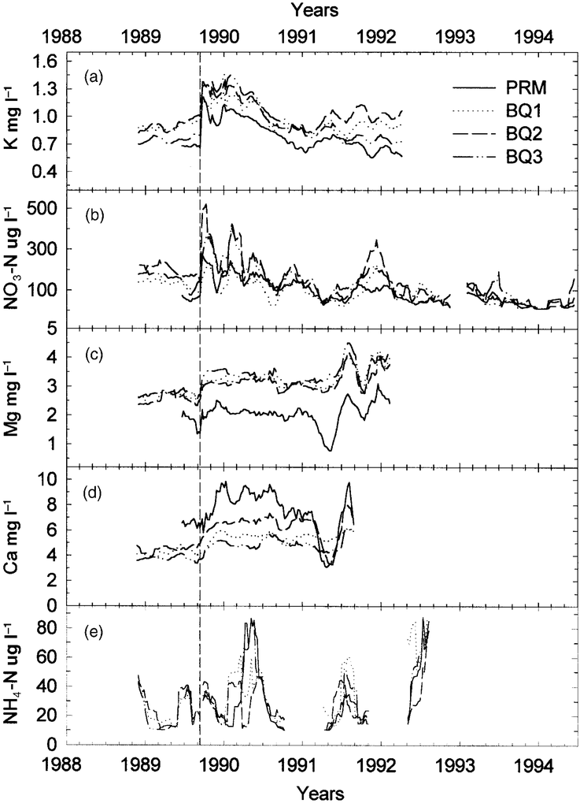

# Description

The project will consist of folders: - Documents - Will include any text - Figures - will include any visuals and saved images - Data - will contain only raw data - Output - will include functions, any renderings, outfitted/cleaned datasets

# Purpose

- The purpose of this project is to recreate the figure from the study and prove accessibility of reproducibility within a 20+ year old study given the data used, the tools such as RStudio and the various libraries.

# Contents

- Contents within the repository will include the raw data in the data folder, functions, analysis scripts, supporting code, cleaned and formatted data and any visuals needed.

# Data Access Details

- Data accessed was sourced at the EDI Data Portal. Specifically relating to the “Chemistry of Stream Water from the Liquillo Mountains. The data recorded weekly water samples and nutrient levels at the Luquillo Mountain before and after a hurricane - The data sets that were used were QuebradaCuenca-Bisley 1,2,3 CSV files

# References

- Data Source https://portal.edirepository.org/nis/mapbrowse?packageid=knb-lter-luq.20.4923064

# Work Cited

McDowell, W. and International Institute of Tropical Forestry(IITF), USDA Forest Service.. 2024. Chemistry of stream water from the Luquillo Mountains ver 4923064. Environmental Data Initiative. https://doi.org/10.6073/pasta/f31349bebdc304f758718f4798d25458 (Accessed 2025-08-25).